# Analyse de Co-inertie (CIA)

Cours de Modélisation Statistique & Application à l’Écologie Fluviale du Doubs

Quentin, Inès, Benjamin

2026-10-15

## Sommaire

I

Cadre d’analyse & Matrices appariées

Dispositif d’échantillonnage du Doubs, matrices Milieu ($X$) et Faune ($Y$), et étape des ACP préalables.

II

Fondements théoriques de la Co-inertie (CIA)

Principe du compromis tripartite (variance-corrélation) et décomposition de l’inertie conjointe par axe.

III

Inférence statistique & Espaces factoriels

Coefficient $RV$ et test de Monte-Carlo, cercles de corrélation (`RVAideMemoire`) et diagnostic stationnel.

IV

Comparatif méthodologique & Bilan

Distinction conceptuelle AFM vs CIA, analyse critique et synthèse générale de la co-inertie.

## 1. Contexte & Localisation : La rivière du Doubs

Partie I : Cadre d’analyse & Matrices appariées

Définition & Dispositif expérimental (Verneaux, 1973)

- **Système d’étude :** Rivière du Doubs (Massif du Jura & frontière franco-suisse).
- **Gradient longitudinal (453 km) :**
  - **Source montagnarde :** Mouthe (altitude 934 m, eaux froides et vives).
  - **Boucle helvétique :** Clos du Doubs (Saint-Ursanne).
  - **Exutoire de plaine :** Confluence Saône (altitude 172 m, eaux calmes).
- **Dispositif apparié :** **$n = 30$ stations** réparties de l’amont vers la plaine.

Problématique scientifique

Comment quantifier et modéliser le couplage entre les gradients physiques du biotope et la structure des communautés écologiques, tout en identifiant les ruptures environnementales locales ?

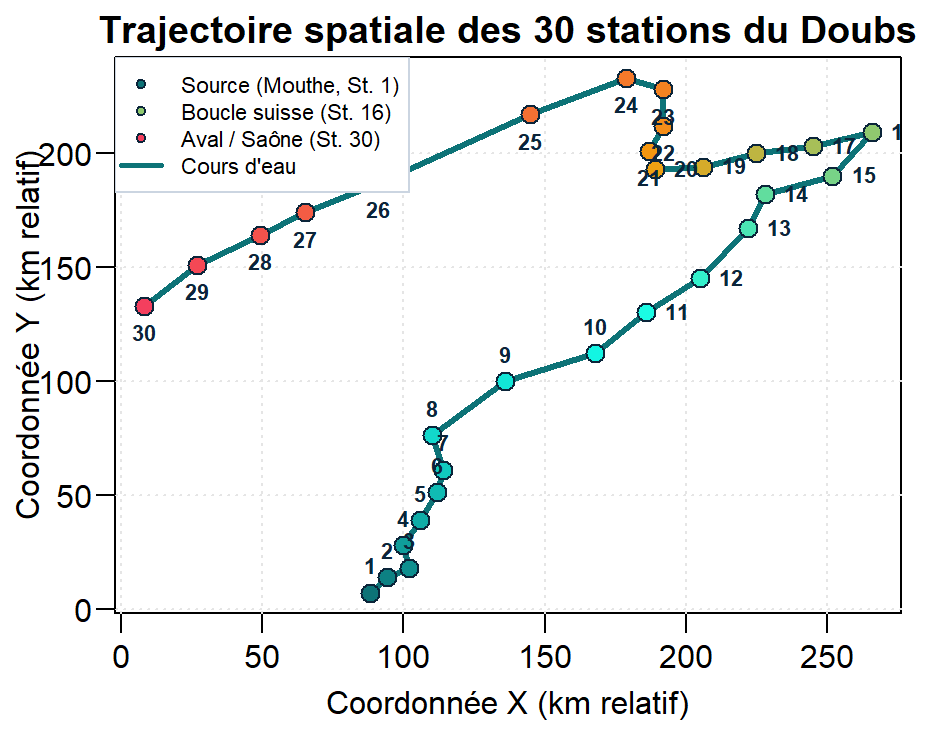

Figure 0 : Profil longitudinal des 30 stations d’échantillonnage

## 2. Données d’étude : Matrice Milieu ($X$)

Caractérisation abiotique du milieu fluvial (**$n = 30$ stations**, 11 variables réelles avec unités physiques corrigées) :

|  | Dist. (km) | Alt. (m) | Débit (m³/s) | pH | O₂ (mg/L) | NO₃⁻ (mg/L) | PO₄³⁻ (mg/L) | NH₄⁺ (mg/L) |
| --- | --- | --- | --- | --- | --- | --- | --- | --- |
| Station 1 | 0.3 | 934 | 0.84 | 7.9 | 12.2 | 0.20 | 0.01 | 0.00 |
| Station 2 | 2.2 | 932 | 1.00 | 8.0 | 10.3 | 0.20 | 0.02 | 0.10 |
| Station 3 | 10.2 | 914 | 1.80 | 8.3 | 10.5 | 0.22 | 0.05 | 0.05 |
| Station 4 | 18.5 | 854 | 2.53 | 8.0 | 11.0 | 0.21 | 0.10 | 0.00 |
| Station 5 | 21.5 | 849 | 2.64 | 8.1 | 8.0 | 0.52 | 0.38 | 0.20 |

Tableau 1a : Matrice $X$ — Descripteurs géomorphologiques et physico-chimiques (30 × 11)

Nature des descripteurs abiotiques

- **11 variables quantitatives continues :**
  - **Morphométrie & hydraulique :** distance à la source (`dfs`), altitude (`alt`), pente (`slo`), débit (`flo`).
  - **Physico-chimie de l’eau :** pH, dureté (`har`), phosphates (`pho`), nitrates (`nit`), ammonium (`amm`), oxygène dissous (`oxy`), DBO₅ (`bdo`).

Hétérogénéité des mesures & Gradients

- **Unités physiques hétérogènes :** mètres ($m$), mètres cubes par seconde ($m^3/s$), milligrammes par litre ($mg/L$), unités pH.
- **Gradients écologiques :**
  - Gradient longitudinal amont $\rightarrow$ aval (altitude, pente vs débit).
  - Gradient trophique et de qualité d’eau (eaux vives oxygénées vs charge organique).

## 3. Données d’étude : Matrice Faune piscicole ($Y$)

Mesures appariées de la communauté ichtyologique (**$n = 30$ stations**, 27 espèces de poissons) :

|  | Truite (Satr) | Vairon (Phph) | Loche (Neba) | Ombre (Thth) | Brochet (Eslu) | Brème (Abbr) | Gardon (Ruru) | Tanche (Titi) |
| --- | --- | --- | --- | --- | --- | --- | --- | --- |
| Station 1 | 3 | 0 | 0 | 0 | 0 | 0 | 0 | 0 |
| Station 2 | 5 | 4 | 3 | 0 | 0 | 0 | 0 | 0 |
| Station 3 | 5 | 5 | 5 | 0 | 1 | 0 | 0 | 0 |
| Station 4 | 4 | 5 | 5 | 0 | 2 | 0 | 0 | 1 |
| Station 5 | 2 | 3 | 2 | 0 | 4 | 0 | 5 | 3 |

Tableau 1b : Matrice $Y$ — Abondances de la communauté ichtyologique (30 stations × 27 espèces)

Caractéristiques de la biocénose

- **Échantillonnage :** **27 espèces de poissons** recensées sur les mêmes **30 stations**.
- **Type de mesure :** Abondances semi-quantitatives en 6 classes ordinales (de 0 = absence à 5 = très forte dominance).
- **Richesse taxonomique :** Faune diversifiée mêlant espèces ubiquistes et taxons indicateurs spécialisés.

Guildes écologiques contrastées

- **Espèces rhéophiles d’amont :** Truite fario (`Satr`), Vairon (`Phph`), Chabot (`Cogo`) — eaux vives, fraîches et très oxygénées.
- **Espèces limnophiles d’aval :** Brème (`Abbr`), Gardon (`Ruru`), Tanche (`Titi`) — eaux lentes, plus tempérées et sédimentaires.

## 4. Étape préalable : Deux ACP séparées pour préparer la Co-inertie

Partie I : Cadre d’analyse & Matrices appariées

Pour réaliser une analyse de co-inertie, **on ne travaille pas directement sur les tableaux bruts** : on réalise d’abord une **ACP séparée sur chaque tableau** pour créer deux espaces factoriels de référence adaptés à la nature des données.

Étape 1 : ACP normée sur le Milieu ($X$)

- **Fonction R :** `dudi.pca(doubs$env, scale = TRUE)`
- **Principe :** Centrage et **réduction par l’écart-type** indispensables car les 11 descripteurs ont des unités physiques disparates ($m$, $mg/L$, $m^3/s$, $pH$).
- **Objectif :** Standardiser les variances à 1 pour donner un poids équivalent à chaque descripteur physique.

Étape 2 : ACP non normée sur la Faune ($Y$)

- **Fonction R :** `dudi.pca(doubs$fish, scale = FALSE)`
- **Principe :** Centrage **sans réduction** car toutes les espèces sont mesurées sur la même échelle (classes d’abondance de 0 à 5).
- **Objectif :** Conserver la variance biologique réelle et respecter la hiérarchie naturelle entre espèces abondantes et rares.

```r
library(ade4)
data(doubs)

# 1. ACP normée sur le milieu (unités hétérogènes)
dudi_env <- dudi.pca(doubs$env, scale = TRUE, scannf = FALSE, nf = 2)

# 2. ACP centrée non normée sur la faune (abondances)
dudi_fau <- dudi.pca(doubs$fish, scale = FALSE, scannf = FALSE, nf = 2)

# 3. La co-inertie couple ces deux espaces factoriels préalables
co_doubs <- coinertia(dudi_env, dudi_fau, scannf = FALSE, nf = 2)
```

## 5. Principe & Définition de la Co-inertie (CIA)

Partie II : Fondements théoriques de la Co-inertie

Définition de la Co-inertie (Dolédec & Chessel, 1994)

L’analyse de co-inertie (CIA) relie deux tableaux de données mesurés sur les mêmes individus (ici les stations). Elle recherche des axes synthétiques communs qui maximisent la **covariance au carré** entre les deux jeux de données :

$$\operatorname{Cov}^2(Xu, Yv) = \underbrace{\operatorname{Var}(Xu)}_{\text{Inertie propre } X} \times \underbrace{\operatorname{Var}(Yv)}_{\text{Inertie propre } Y} \times \underbrace{\operatorname{Corr}^2(Xu, Yv)}_{\text{Corrélation au carré}}$$

En résumé : les points clés

- **Un compromis tripartite équilibré :** Pour identifier une liaison forte, la méthode exige à la fois une forte variabilité dans le milieu ($X$), une forte variabilité dans la faune ($Y$) et une corrélation élevée entre les deux.
- **Une approche symétrique :** Aucun tableau n’est privilégié ou posé comme variable réponse ($Y = f(X)$) ; les deux jeux de données sont traités sur un pied d’égalité.
- **Stabilité et robustesse :** En combinant variance et corrélation, la co-inertie reste stable et évite d’isoler des axes artificiels, même lorsqu’il y a plus de variables que de stations ($p + q > n$).

## 6. Décomposition de l’inertie conjointe

```r
# 1. Analyse conjointe sur 5 axes
co_doubs <- coinertia(dudi_env, dudi_fau, scannf = FALSE, nf = 5)
```

- **Axe 1 :** **88.4 %** de l’inertie conjointe.
- **Axe 2 :** **10.3 %** de l’inertie conjointe.
- **Cumul 1-2 :** **98.7 %** de la co-structure totale !
- **Axes 3 à 5 :** Moins de 1.5 % résiduel (bruit non structurant).
- **Décision :** Deux dimensions suffisent amplement à résumer toute la liaison écologique ($nf = 2$).

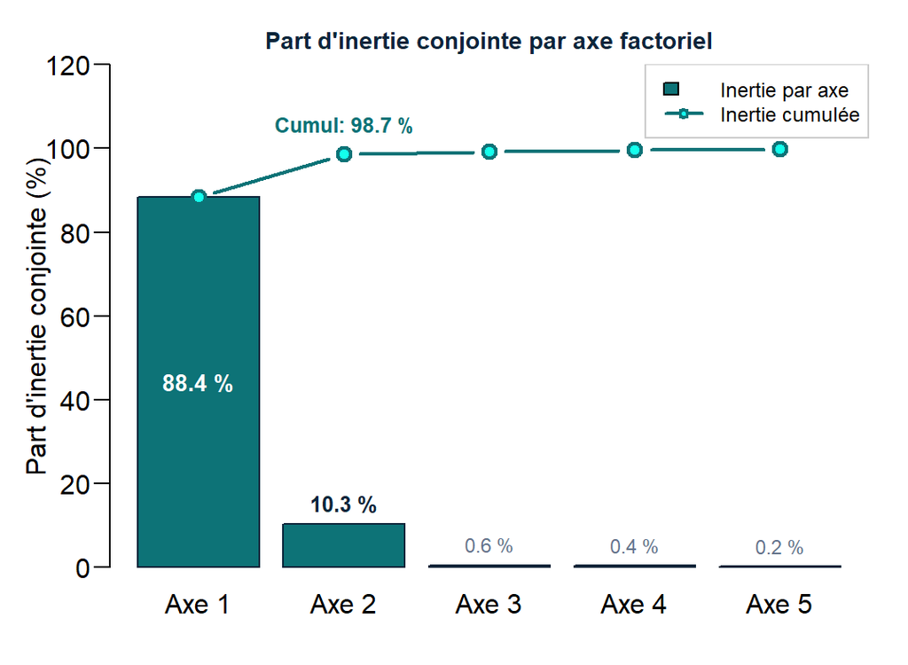

Figure 1 : Évolution de l’inertie conjointe et cumulée par axe

## 7. Inférence statistique : Coefficient $RV$ & Test de Monte-Carlo

Définition du Coefficient $RV$ (Escoufier, 1973)

Le coefficient $RV$ mesure le **degré de liaison globale** entre les deux tableaux de données mesurés sur les mêmes stations.

$$RV \in [0, 1] \quad (\text{analogue d'un } R^2 \text{ multivarié})$$

- **$RV = 0$ :** Indépendance totale entre les deux tableaux.
- **$RV = 1$ :** Concordance parfaite entre les deux structures.

En résumé : interprétation & test

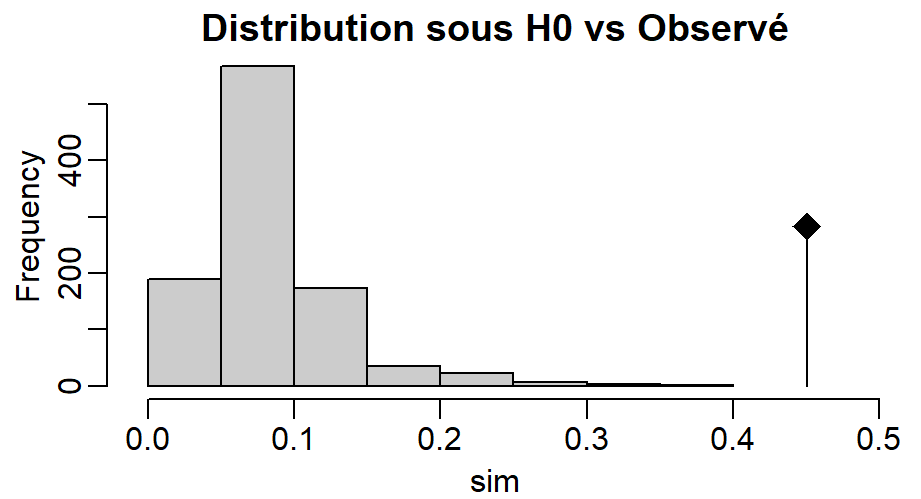

```r
set.seed(123)
test_rv <- randtest(co_doubs, nrepet = 999)
par(mar = c(2.6, 2.8, 1.4, 1), mgp = c(1.6, 0.5, 0))
plot(test_rv, main = "Distribution sous H0 vs Observé")
```

Résultat du test de Monte-Carlo

- **Permutations :** 999 permutations aléatoires des stations.
- **Significativité :** **$p = 0.001$**. Le lien observé est nettement supérieur à ce que donnerait le hasard : la co-structure biotope-biocénose est statistiquement validée.

## 8. Projection des variables & Cercles de corrélation (`RVAideMemoire`)

Partie III : Inférence statistique & Espaces factoriels

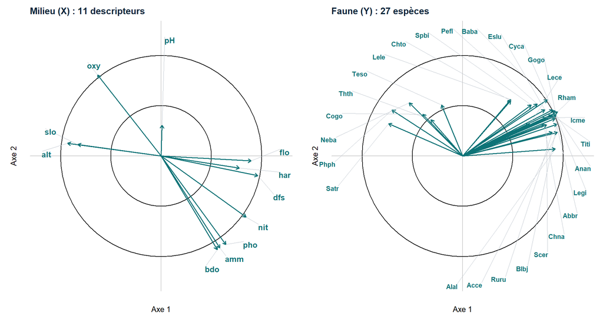

## 9. Synthèse numérique de la CIA : la fonction `MVA.synt`

Partie III : Inférence statistique & Espaces factoriels

```r
library(RVAideMemoire)

# Synthèse de la co-inertie : corrélations entre paires d'axes
synt  <- MVA.synt(co_doubs)
tab_ax <- synt[[3]]$tab

colnames(tab_ax) <- c("Paire", "r")
tab_ax[, 2] <- round(tab_ax[, 2], 4)
kable(tab_ax, align = "c")
```

| Paire | r |
| --- | --- |
| 1 | 0.7302 |
| 2 | 0.7718 |
| 3 | 0.5547 |
| 4 | 0.6725 |
| 5 | 0.5073 |

## 10. Espace de compromis : Diagnostic stationnel (Individus)

```r
# Projection vectorielle des 30 stations sous ade4
plot(co_doubs$mX, type = "n", xlim = xlim, ylim = ylim,
     xlab = "Axe 1 (88.4 %)", ylab = "Axe 2 (10.3 %)")
arrows(co_doubs$mX[,1], co_doubs$mX[,2],
       co_doubs$mY[,1], co_doubs$mY[,2], col = cols, lwd = 1.8)
points(co_doubs$mX, pch = 21, bg = cols, cex = 1.2) # Milieu X
points(co_doubs$mY, pch = 17, col = cols, cex = 1.1) # Faune Y
```

Diagnostic des résidus écologiques

- **Repères :** Cercles = Milieu attendu ($X$) ; Triangles = Faune observée ($Y$).
- **Flèches courtes :** Concordance biotope-biocénose (secteurs amont et cours d’eau équilibrés).
- **Flèches longues (découplage stationnel) :**
  - **Station 8 :** Absence totale de faune (assèchement périodique karstique).
  - **Stations 23 à 25 :** Rejets polluants induisant une rupture locale marquée.

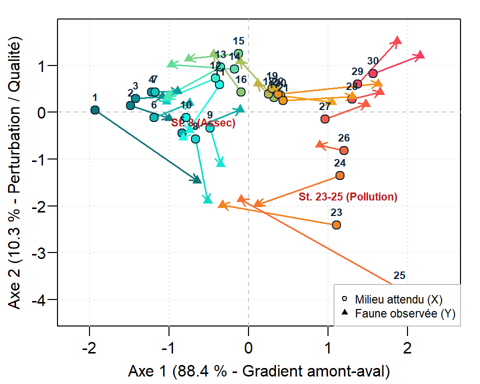

Figure 3 : Plan de compromis des 30 stations du Doubs

## 11. Comparatif méthodologique : AFM vs CIA (Co-inertie)

Partie IV : Comparatif méthodologique & Bilan

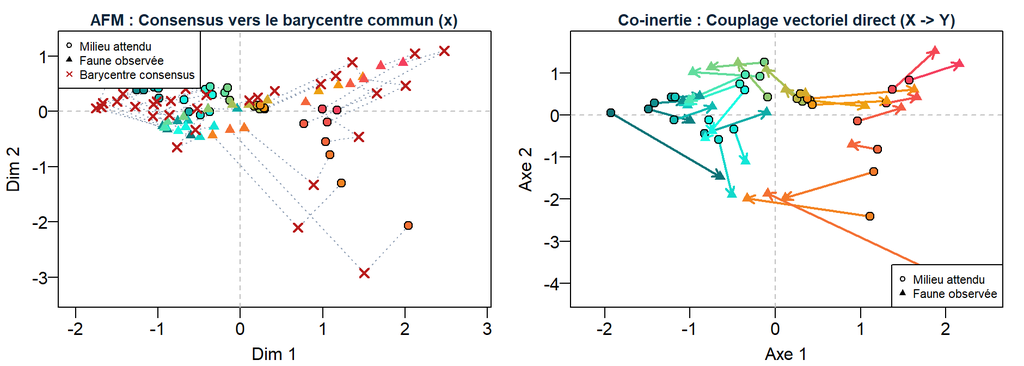

AFM (Compromis barycentrique)

Pondère chaque tableau par son premier axe propre ($1/\lambda_1$). Recherche une représentation consensuelle moyenne où les discordances locales sont atténuées vers le barycentre commun.

Co-inertie (Couplage vectoriel direct)

Maximise directement la covariance croisée. Isole explicitement la direction et l’amplitude des anomalies individuelles ($X \rightarrow Y$) sans lissage consensuel.

## 12. Bilan méthodologique de la Co-inertie

Atouts majeurs de la méthode (Pour)

- **Adaptée aux grands jeux de données :** Fonctionne sans difficulté même lorsqu’il y a beaucoup plus de variables que d’observations ($p, q \gg n$).
- **Insensible à la colinéarité :** Les fortes redondances entre variables au sein d’un même tableau ne bloquent pas l’analyse.
- **Grande souplesse :** S’adapte à différents types de données grâce au choix de l’ordination préalable (ACP, AFC, ACM…).
- **Outil de diagnostic vectoriel :** Les flèches permettent de visualiser directement les stations en équilibre et les anomalies écologiques locales.

Précautions et limites d’usage (Contre)

- **Appariement strict obligatoire :** Les deux tableaux doivent impérativement être mesurés sur les **mêmes individus** (mêmes stations échantillonnées).
- **Absence de causalité :** Méthode purement descriptive et symétrique : elle montre des covariations mais **ne peut pas rendre compte de la causalité** ($Y = f(X)$).
- **Sensibilité aux valeurs extrêmes :** Une observation atypique peut exercer une inertie disproportionnée et orienter les axes.
- **Pas de sélection de variables :** Toutes les variables sont conservées sans tri automatique préalable.

## 13. Synthèse & Bilan de la Co-inertie (CIA)

Partie IV : Comparatif méthodologique & Bilan

Fondements méthodologiques

- **Principe central :** Recherche d’un système d’axes factoriels communs maximisant la **covariance au carré** ($\operatorname{Cov}^2$) entre deux tableaux mesurés sur les mêmes individus.
- **Compromis tripartite optimal :** Combine simultanément une forte inertie propre dans chaque tableau ($\operatorname{Var}$) et une corrélation maximale entre eux ($\operatorname{Corr}^2$).
- **Rôle parfaitement symétrique :** Aucun tableau n’est posé comme variable à prédire ($Y = f(X)$) ; les deux jeux de variables sont traités sur un pied d’égalité.
- **Flexibilité des ordinations préalables :** S’adapte à la nature mathématique de chaque tableau (ACP normée si unités hétérogènes, ACP centrée, AFC, ACM…).

Recommandations & Points clés

- **Performance en haute dimension :** Fonctionne de manière stable sans inversion matricielle, même lorsqu’il y a beaucoup plus de variables que d’observations ($p, q \gg n$).
- **Validation par permutation ($RV$) :** Étape obligatoire avant d’interpréter les axes factoriels afin de prouver que la co-structure globale n’est pas due au hasard.
- **Diagnostic visuel vectoriel :** L’espace de compromis révèle directement les individus en accord (flèches courtes) et les discordances locales (flèches longues).
- **Démarche exploratoire :** Révèle des structures communes et des patrons de covariation, sans pouvoir affirmer de relation de causalité directe.

## Bibliographie

I

HERVÉ, Maxime, “Aide-mémoire de statistique appliquée à la biologie”, p.193-195

https://archive.linux.duke.edu/pub/cran/doc/contrib/Herve-Aide-memoire-statistique.pdf?

II

CHESSEL, Daniel, DUFOUR, A.-B, “Co-inertie, co-structures et compromis”, p.2-10

https://esb.univ-lyon1.fr/pdf/cssb8.pdf

III

CHESSEL, Daniel, “Ichtyofaune du bassin du Doubs”

https://esb.univ-lyon1.fr/pdf/pps047.pdf

IV

C CULHANE, Aedin, PERRIERE, Guy, G HIGGINS, Desmond, “Cross-platform comparison and visualisation of gene expression data using co-inertia analysis”

https://pmc.ncbi.nlm.nih.gov/articles/PMC317282/

## Bibliographie (suite)

V

DUFOUR, A.B, “Coinertia Analysis”

https://esb.univ-lyon1.fr/pdf/course6.pdf

VI

DRAY, Stéphane, CHESSEL, Daniel, THIOULOUSE, Jean, “CO-INERTIA ANALYSIS AND THE LINKING OF ECOLOGICAL DATA TABLES”

https://hal.science/hal-00427392v1

VII

CHESSEL, Daniel, DUFOUR, A.-B., “Pratique de l’analyse des correspondances”

https://esb.univ-lyon1.fr/pdf/tdr62.pdf

## Annexe A. Synthèse écologique : Zonation de Huet & Continuum fluvial

L’ordination factorielle de co-inertie valide les modèles théoriques de l’écologie des eaux courantes :

| Zone écologique | Secteur du Doubs | Conditions abiotiques | Taxons indicateurs |
| --- | --- | --- | --- |
| 1. Zone à Truite | Amont (St. 1 - 10) | Pente forte, eau froide, O₂ saturé | Truite (Satr), Chabot (Cogo), Vairon (Phph) |
| 2. Zone à Ombre | Haut-cours (St. 11 - 18) | Courant vif, substrat graveleux | Ombre (Thth), Hotu (Chna), Blageon (Teso) |
| 3. Zone à Barbeau | Moyen-cours (St. 19 - 22) | Courant modéré, lit élargi | Barbeau (Baba), Chevesne (Lece), Spirlin (Spbi) |
| 4. Zone à Brème | Aval / Plaine (St. 26 - 30) | Pente faible, eau turbide, limons | Brème (Abbr), Gardon (Ruru), Tanche (Titi) |

- **Axe 1 (88.4 % de co-structure) — River Continuum Concept (Vannote et al., 1980) :** Continuum fluvial morphodynamique structurant la transition ordonnée des salmonidés rhéophiles vers les cyprinidés limnophiles.
- **Axe 2 (10.3 % de co-structure) — Perturbations anthropiques :** Déviation orthogonale locale au gradient sous l’effet de pollutions organiques ponctuelles.

## Annexe B. Mécanismes physico-chimiques : Rupture aux stations 23–25

| Secteur | O₂ | NH₄⁺ | PO₄³⁻ | DBO₅ |
| --- | --- | --- | --- | --- |
| Amont sain (1-15) | 10.5 mg/L | 0.04 mg/L | 0.16 mg/L | 3.6 mg/L |
| St. 23 | 6.3 mg/L | 1.15 mg/L | 2.60 mg/L | 16.4 mg/L |
| St. 24 | 5.2 mg/L | 0.60 mg/L | 1.40 mg/L | 12.3 mg/L |
| St. 25 (Pic) | 4.1 mg/L | 1.80 mg/L | 4.22 mg/L | 16.7 mg/L |

- **Hypoxie critique ($O_2 < 5$ mg/L) :** Asphyxie des salmonidés sténothermes (`Satr`, `Cogo`) qui requièrent $> 8$ mg/L.
- **Toxicité ammoniacale ($NH_4^+ \rightarrow NH_3$) :** Lésions branchiales et perturbation du métabolisme azoté.
- **Impact faunistique :** Élimination sélective des espèces sensibles au profit exclusif de cyprinidés euryèces tolérants (`Lece`, `Ruru`, `Alal`).

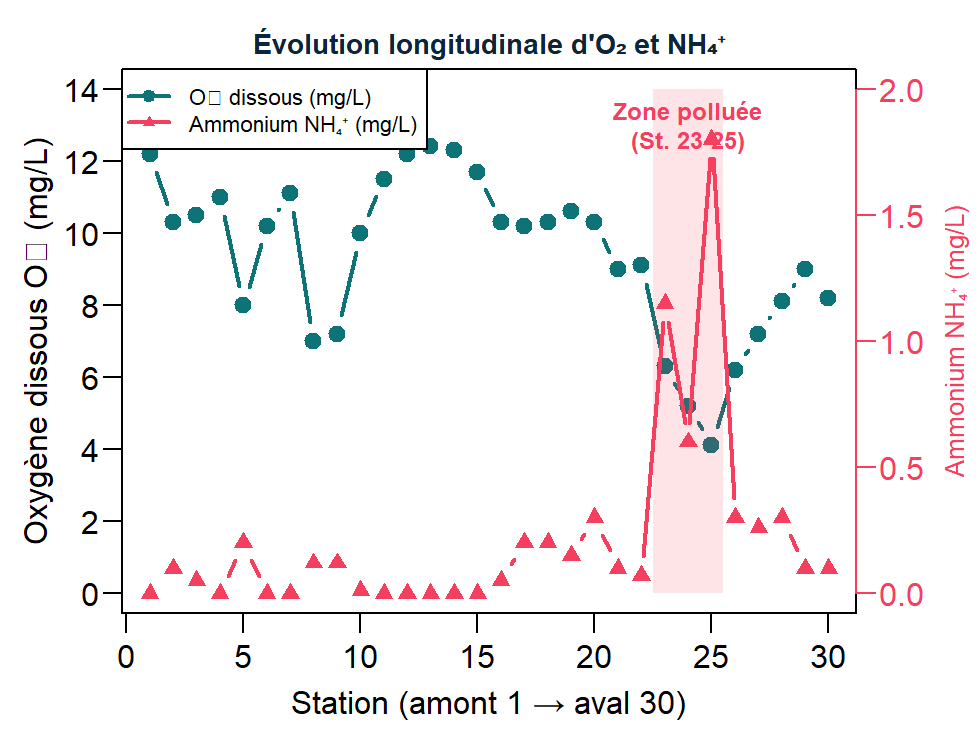

Figure 3 : Rupture chimique aux stations 23 à 25

## Annexe C. Code R complet : Cercles de corrélation de la CIA

Annexe technique

Le code de la slide 8 est reproduit ci-dessous : les corrélations proviennent de `RVAideMemoire::MVA.cor()`, l’annotation en anneau des variables est réalisée par la fonction `ring_labels()`.

**1. Extraction des corrélations et annotation en anneau**

```r
library(RVAideMemoire)

# Corrélations (variables x axes de co-inertie)
cor_x <- MVA.cor(co_doubs, space = 1)$corr[, 1:2]   # Milieu : 11 descripteurs
cor_y <- MVA.cor(co_doubs, space = 2)$corr[, 1:2]   # Faune : 27 espèces
lab_x <- rownames(cor_x)
lab_y <- rownames(cor_y)

# Couleur unique pour toutes les variables
col_x <- rep("#0d7377", length(lab_x))
col_y <- rep("#0d7377", length(lab_y))

# Annotation en anneau : écart angulaire minimal = largeur du texte
ring_labels <- function(x, y, labels, cex = 0.70, r_lab = 1.10, gap = 0.192) {
  usr <- par("usr"); pin <- par("pin")
  sx <- pin[1] / diff(usr[1:2])      # pouces par unité de données (axe x)
  sy <- pin[2] / diff(usr[3:4])      # pouces par unité de données (axe y)
  ang <- atan2(y * sy, x * sx)       # angle mesuré dans l'espace d'affichage
  ord <- order(ang); n <- length(ang); a <- ang[ord]
  w <- strwidth(labels, cex = cex, units = "inches")
  rin <- r_lab * sx                  # rayon de l'anneau, en pouces
  gapr <- max(gap, max(w) / rin, 0.10)
  for (it in 1:6000) {               # espacement sur le cercle
    d <- diff(c(a, a[1] + 2 * pi)); bad <- which(d < gapr - 1e-9)
    if (!length(bad)) break
    for (k in bad) {
      push <- (gapr - d[k]) / 2
      a[k] <- a[k] - push
      j <- if (k == n) 1 else k + 1; a[j] <- a[j] + push
    }
  }
  aout <- numeric(n); aout[ord] <- a
  data.frame(x = r_lab * cos(aout), y = r_lab * sin(aout),
             ax = x, ay = y,
             adjx = ifelse(cos(aout) >= 0, 0.04, 0.96))
}
```

**2. Tracé des deux cercles**

```r
# Cercle de corrélation (vrai cercle grâce à asp = 1)
circle_CIA <- function(cor, lab, col, main, cex = 0.70, r_lab = 1.24) {
  plot(cor[, 1], cor[, 2], type = "n", xlim = c(-1.30, 1.30),
       ylim = c(-1.30, 1.30), asp = 1, axes = FALSE,
       xlab = "", ylab = "", xaxs = "i", yaxs = "i")
  mtext(c("Axe 1", "Axe 2"), side = c(1, 2), line = 1.0, at = 0, cex = 0.8)
  abline(v = 0, h = 0, col = "grey80")
  symbols(0, 0, circles = 1, inches = FALSE, add = TRUE)
  symbols(0, 0, circles = 0.5, inches = FALSE, lty = 3, add = TRUE)
  arrows(0, 0, cor[, 1], cor[, 2], length = 0.06, col = col, lwd = 1.8)
  p <- ring_labels(cor[, 1], cor[, 2], lab, cex = cex, r_lab = r_lab)
  # lignes de rappel puis étiquettes à l'extérieur du cercle
  segments(p$ax, p$ay, p$x, p$y, col = "#b8c0c9", lwd = 0.6)
  text(p$x, p$y, labels = lab, cex = cex, col = col, font = 2,
       adj = c(p$adjx, 0.5), xpd = NA)
  title(main, adj = 0, line = 0.6, cex.main = 0.95, col.main = "#0b253a")
}

par(mfrow = c(1, 2), mar = c(2.2, 2.6, 1.8, 0.8), oma = c(0.2, 0, 0, 0))
circle_CIA(cor_x, lab_x, col_x, "Milieu (X) : 11 descripteurs",
           cex = 0.82, r_lab = 1.18)
circle_CIA(cor_y, lab_y, col_y, "Faune (Y) : 27 espèces",
           cex = 0.68, r_lab = 1.27)
```

Points clés de l’implémentation

- `MVA.cor(dudi, space = 1|2)` renvoie la matrice des corrélations variables × axes de co-inertie (c’est cette matrice qui est projetée, et non `MVA.corplot` directement).
- `asp = 1` impose un rapport d’aspect égal : sans lui, `symbols(circles = 1)` dessine une **ellipse**.
- `strwidth(..., units = "inches")` est indispensable : par défaut `strwidth()` renvoie des **unités utilisateur**, ce qui sous-estime la largeur du texte et provoque les superpositions d’étiquettes.
- `xpd = NA` autorise l’écriture des étiquettes hors de la zone de tracé.